# Risk Factor Analysis

## Outcome Variable

**Outcome Variable:** ever_swasted

## Predictor Variables

**Intervention Variable:** gagebrth

**Adjustment Set:**

- arm
- sex
- W_mage
- meducyrs
- feducyrs
- hhwealth_quart
- W_nrooms
- W_nchldlt5
- brthmon
- W_parity
- impsan
- delta_W_mage
- delta_meducyrs
- delta_feducyrs
- delta_hhwealth_quart
- delta_W_nrooms
- delta_W_nchldlt5
- delta_brthmon
- delta_W_parity
- delta_impsan

## Stratifying Variables

The analysis was stratified on these variable(s):

- agecat
- studyid
- country

## Data Summary

| agecat | studyid | country | gagebrth | ever_swasted | n_cell | n |
| --- | --- | --- | --- | --- | --- | --- |
| 0-24 months (no birth wast) | CMC-V-BCS-2002 | INDIA | Full or late term | 0 | 183 | 348 |
| 0-24 months (no birth wast) | CMC-V-BCS-2002 | INDIA | Full or late term | 1 | 30 | 348 |
| 0-24 months (no birth wast) | CMC-V-BCS-2002 | INDIA | Preterm | 0 | 42 | 348 |
| 0-24 months (no birth wast) | CMC-V-BCS-2002 | INDIA | Preterm | 1 | 10 | 348 |
| 0-24 months (no birth wast) | CMC-V-BCS-2002 | INDIA | Early term | 0 | 71 | 348 |
| 0-24 months (no birth wast) | CMC-V-BCS-2002 | INDIA | Early term | 1 | 12 | 348 |
| 0-24 months (no birth wast) | COHORTS | GUATEMALA | Full or late term | 0 | 441 | 809 |
| 0-24 months (no birth wast) | COHORTS | GUATEMALA | Full or late term | 1 | 7 | 809 |
| 0-24 months (no birth wast) | COHORTS | GUATEMALA | Preterm | 0 | 126 | 809 |
| 0-24 months (no birth wast) | COHORTS | GUATEMALA | Preterm | 1 | 4 | 809 |
| 0-24 months (no birth wast) | COHORTS | GUATEMALA | Early term | 0 | 222 | 809 |
| 0-24 months (no birth wast) | COHORTS | GUATEMALA | Early term | 1 | 9 | 809 |
| 0-24 months (no birth wast) | COHORTS | INDIA | Full or late term | 0 | 556 | 1345 |
| 0-24 months (no birth wast) | COHORTS | INDIA | Full or late term | 1 | 23 | 1345 |
| 0-24 months (no birth wast) | COHORTS | INDIA | Preterm | 0 | 294 | 1345 |
| 0-24 months (no birth wast) | COHORTS | INDIA | Preterm | 1 | 14 | 1345 |
| 0-24 months (no birth wast) | COHORTS | INDIA | Early term | 0 | 433 | 1345 |
| 0-24 months (no birth wast) | COHORTS | INDIA | Early term | 1 | 25 | 1345 |
| 0-24 months (no birth wast) | COHORTS | PHILIPPINES | Full or late term | 0 | 1073 | 2993 |
| 0-24 months (no birth wast) | COHORTS | PHILIPPINES | Full or late term | 1 | 85 | 2993 |
| 0-24 months (no birth wast) | COHORTS | PHILIPPINES | Preterm | 0 | 581 | 2993 |
| 0-24 months (no birth wast) | COHORTS | PHILIPPINES | Preterm | 1 | 52 | 2993 |
| 0-24 months (no birth wast) | COHORTS | PHILIPPINES | Early term | 0 | 1093 | 2993 |
| 0-24 months (no birth wast) | COHORTS | PHILIPPINES | Early term | 1 | 109 | 2993 |
| 0-24 months (no birth wast) | IRC | INDIA | Full or late term | 0 | 206 | 389 |
| 0-24 months (no birth wast) | IRC | INDIA | Full or late term | 1 | 43 | 389 |
| 0-24 months (no birth wast) | IRC | INDIA | Preterm | 0 | 34 | 389 |
| 0-24 months (no birth wast) | IRC | INDIA | Preterm | 1 | 8 | 389 |
| 0-24 months (no birth wast) | IRC | INDIA | Early term | 0 | 74 | 389 |
| 0-24 months (no birth wast) | IRC | INDIA | Early term | 1 | 24 | 389 |

[output cut: 150 more lines]

The following strata were considered:

- agecat: 0-24 months (no birth wast), studyid: CMC-V-BCS-2002, country: INDIA
- agecat: 0-24 months (no birth wast), studyid: COHORTS, country: GUATEMALA
- agecat: 0-24 months (no birth wast), studyid: COHORTS, country: INDIA
- agecat: 0-24 months (no birth wast), studyid: COHORTS, country: PHILIPPINES
- agecat: 0-24 months (no birth wast), studyid: IRC, country: INDIA
- agecat: 0-24 months (no birth wast), studyid: JiVitA-3, country: BANGLADESH
- agecat: 0-24 months (no birth wast), studyid: Keneba, country: GAMBIA
- agecat: 0-24 months (no birth wast), studyid: NIH-Crypto, country: BANGLADESH
- agecat: 0-24 months (no birth wast), studyid: PROBIT, country: BELARUS
- agecat: 0-24 months (no birth wast), studyid: TanzaniaChild2, country: TANZANIA, UNITED REPUBLIC OF
- agecat: 0-6 months (no birth wast), studyid: CMC-V-BCS-2002, country: INDIA
- agecat: 0-6 months (no birth wast), studyid: COHORTS, country: GUATEMALA
- agecat: 0-6 months (no birth wast), studyid: COHORTS, country: INDIA
- agecat: 0-6 months (no birth wast), studyid: COHORTS, country: PHILIPPINES
- agecat: 0-6 months (no birth wast), studyid: IRC, country: INDIA
- agecat: 0-6 months (no birth wast), studyid: JiVitA-3, country: BANGLADESH
- agecat: 0-6 months (no birth wast), studyid: Keneba, country: GAMBIA
- agecat: 0-6 months (no birth wast), studyid: NIH-Crypto, country: BANGLADESH
- agecat: 0-6 months (no birth wast), studyid: PROBIT, country: BELARUS
- agecat: 0-6 months (no birth wast), studyid: TanzaniaChild2, country: TANZANIA, UNITED REPUBLIC OF
- agecat: 6-24 months, studyid: CMC-V-BCS-2002, country: INDIA
- agecat: 6-24 months, studyid: COHORTS, country: GUATEMALA
- agecat: 6-24 months, studyid: COHORTS, country: INDIA
- agecat: 6-24 months, studyid: COHORTS, country: PHILIPPINES
- agecat: 6-24 months, studyid: IRC, country: INDIA
- agecat: 6-24 months, studyid: JiVitA-3, country: BANGLADESH
- agecat: 6-24 months, studyid: Keneba, country: GAMBIA
- agecat: 6-24 months, studyid: NIH-Crypto, country: BANGLADESH
- agecat: 6-24 months, studyid: PROBIT, country: BELARUS
- agecat: 6-24 months, studyid: TanzaniaChild2, country: TANZANIA, UNITED REPUBLIC OF

### Dropped Strata

Some strata were dropped due to rare outcomes:

- agecat: 0-24 months (no birth wast), studyid: COHORTS, country: GUATEMALA
- agecat: 0-24 months (no birth wast), studyid: NIH-Crypto, country: BANGLADESH
- agecat: 0-6 months (no birth wast), studyid: CMC-V-BCS-2002, country: INDIA
- agecat: 0-6 months (no birth wast), studyid: COHORTS, country: GUATEMALA
- agecat: 0-6 months (no birth wast), studyid: COHORTS, country: INDIA
- agecat: 0-6 months (no birth wast), studyid: NIH-Crypto, country: BANGLADESH
- agecat: 6-24 months, studyid: NIH-Crypto, country: BANGLADESH
- agecat: 6-24 months, studyid: PROBIT, country: BELARUS

## Methods Detail

We’re interested in the causal parameters $E[Y_a]$ for all values of $a \in \mathcal{A}$. These parameters represent the mean outcome if, possibly contrary to fact, we intervened to set all units to have $A=a$. Under the randomization and positivity assumptions, these are identified by the statistical parameters $\psi_a=E_W[E_{Y|A,W}(Y|A=a,W)]$. In addition, we’re interested in the mean of $Y$, $E[Y]$ under no intervention (the observed mean). We will estimate these parameters by using SuperLearner to fit the relevant likelihood factors – $E_{Y|A,W}(Y|A=a,W)$ and $p(A=a|W)$, and then updating our likelihood fit using a joint TMLE.

For unadjusted analyses ($W=\{\}$), initial likelihoods were estimated using Lrnr_glm to estimate the simple $E(Y|A)$ and Lrnr_mean to estimate $p(A)$. For adjusted analyses, a small library containing Lrnr_glmnet, Lrnr_xgboost, and Lrnr_mean was used.

Having estimated these parameters, we will then use the delta method to estimate relative risks and attributable risks relative to a prespecified baseline level of $A$.

# Results Detail

## Results Plots

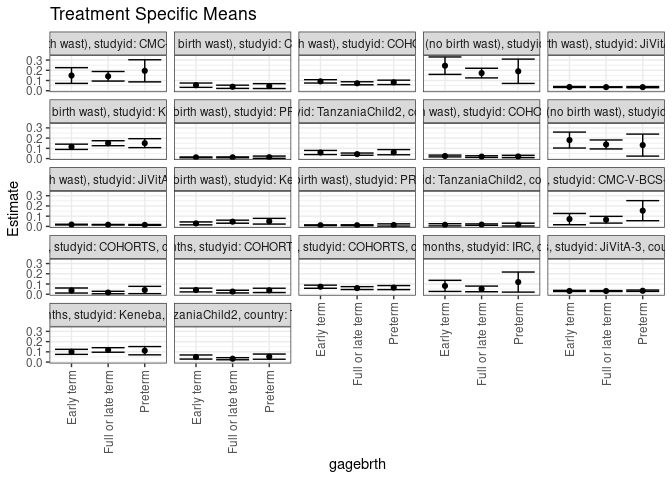

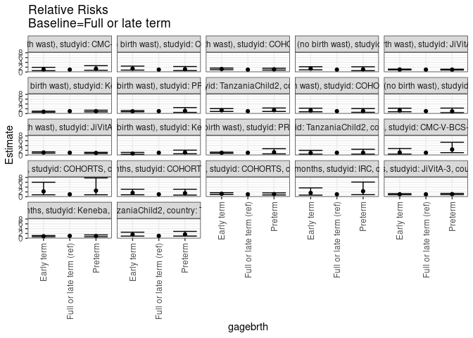

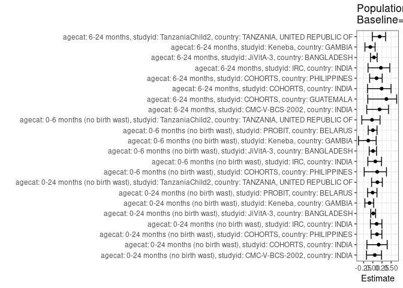

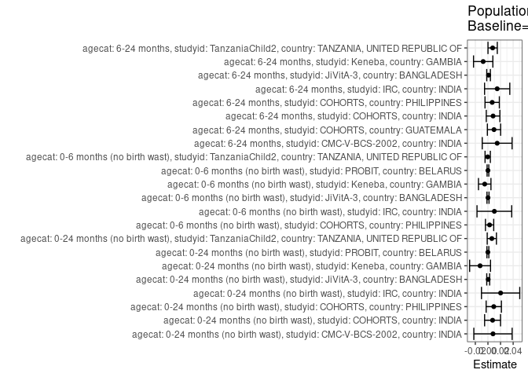

## Results Table

### Parameter: TSM

| agecat | studyid | country | intervention_level | baseline_level | estimate | ci_lower | ci_upper |
| --- | --- | --- | --- | --- | --- | --- | --- |
| 0-24 months (no birth wast) | CMC-V-BCS-2002 | INDIA | Full or late term | NA | 0.1414191 | 0.0945370 | 0.1883011 |
| 0-24 months (no birth wast) | CMC-V-BCS-2002 | INDIA | Preterm | NA | 0.1947260 | 0.0866866 | 0.3027654 |
| 0-24 months (no birth wast) | CMC-V-BCS-2002 | INDIA | Early term | NA | 0.1486504 | 0.0716610 | 0.2256397 |
| 0-24 months (no birth wast) | COHORTS | INDIA | Full or late term | NA | 0.0387457 | 0.0229167 | 0.0545747 |
| 0-24 months (no birth wast) | COHORTS | INDIA | Preterm | NA | 0.0453042 | 0.0214939 | 0.0691144 |
| 0-24 months (no birth wast) | COHORTS | INDIA | Early term | NA | 0.0541269 | 0.0331126 | 0.0751412 |
| 0-24 months (no birth wast) | COHORTS | PHILIPPINES | Full or late term | NA | 0.0729398 | 0.0579697 | 0.0879099 |
| 0-24 months (no birth wast) | COHORTS | PHILIPPINES | Preterm | NA | 0.0819199 | 0.0604912 | 0.1033486 |
| 0-24 months (no birth wast) | COHORTS | PHILIPPINES | Early term | NA | 0.0916373 | 0.0754454 | 0.1078291 |
| 0-24 months (no birth wast) | IRC | INDIA | Full or late term | NA | 0.1726908 | 0.1256823 | 0.2196992 |
| 0-24 months (no birth wast) | IRC | INDIA | Preterm | NA | 0.1904762 | 0.0715664 | 0.3093860 |
| 0-24 months (no birth wast) | IRC | INDIA | Early term | NA | 0.2448980 | 0.1596489 | 0.3301470 |
| 0-24 months (no birth wast) | JiVitA-3 | BANGLADESH | Full or late term | NA | 0.0352716 | 0.0317564 | 0.0387867 |
| 0-24 months (no birth wast) | JiVitA-3 | BANGLADESH | Preterm | NA | 0.0350161 | 0.0296522 | 0.0403799 |
| 0-24 months (no birth wast) | JiVitA-3 | BANGLADESH | Early term | NA | 0.0364665 | 0.0316034 | 0.0413296 |
| 0-24 months (no birth wast) | Keneba | GAMBIA | Full or late term | NA | 0.1501742 | 0.1259307 | 0.1744177 |
| 0-24 months (no birth wast) | Keneba | GAMBIA | Preterm | NA | 0.1506375 | 0.1067854 | 0.1944896 |
| 0-24 months (no birth wast) | Keneba | GAMBIA | Early term | NA | 0.1150659 | 0.0894518 | 0.1406800 |
| 0-24 months (no birth wast) | PROBIT | BELARUS | Full or late term | NA | 0.0121796 | 0.0079391 | 0.0164200 |
| 0-24 months (no birth wast) | PROBIT | BELARUS | Preterm | NA | 0.0135364 | 0.0026530 | 0.0244198 |
| 0-24 months (no birth wast) | PROBIT | BELARUS | Early term | NA | 0.0118690 | 0.0079340 | 0.0158041 |
| 0-24 months (no birth wast) | TanzaniaChild2 | TANZANIA, UNITED REPUBLIC OF | Full or late term | NA | 0.0433609 | 0.0326435 | 0.0540783 |
| 0-24 months (no birth wast) | TanzaniaChild2 | TANZANIA, UNITED REPUBLIC OF | Preterm | NA | 0.0625611 | 0.0370003 | 0.0881218 |
| 0-24 months (no birth wast) | TanzaniaChild2 | TANZANIA, UNITED REPUBLIC OF | Early term | NA | 0.0592962 | 0.0390404 | 0.0795520 |
| 0-6 months (no birth wast) | COHORTS | PHILIPPINES | Full or late term | NA | 0.0192654 | 0.0112598 | 0.0272710 |
| 0-6 months (no birth wast) | COHORTS | PHILIPPINES | Preterm | NA | 0.0204930 | 0.0094549 | 0.0315312 |
| 0-6 months (no birth wast) | COHORTS | PHILIPPINES | Early term | NA | 0.0250963 | 0.0162272 | 0.0339655 |
| 0-6 months (no birth wast) | IRC | INDIA | Full or late term | NA | 0.1380753 | 0.0942800 | 0.1818707 |
| 0-6 months (no birth wast) | IRC | INDIA | Preterm | NA | 0.1315789 | 0.0239570 | 0.2392009 |
| 0-6 months (no birth wast) | IRC | INDIA | Early term | NA | 0.1808511 | 0.1029377 | 0.2587645 |
| 0-6 months (no birth wast) | JiVitA-3 | BANGLADESH | Full or late term | NA | 0.0163220 | 0.0138330 | 0.0188109 |
| 0-6 months (no birth wast) | JiVitA-3 | BANGLADESH | Preterm | NA | 0.0146698 | 0.0111675 | 0.0181720 |
| 0-6 months (no birth wast) | JiVitA-3 | BANGLADESH | Early term | NA | 0.0176752 | 0.0142315 | 0.0211190 |
| 0-6 months (no birth wast) | Keneba | GAMBIA | Full or late term | NA | 0.0460000 | 0.0312440 | 0.0607561 |
| 0-6 months (no birth wast) | Keneba | GAMBIA | Preterm | NA | 0.0505948 | 0.0227872 | 0.0784025 |
| 0-6 months (no birth wast) | Keneba | GAMBIA | Early term | NA | 0.0294425 | 0.0152121 | 0.0436728 |
| 0-6 months (no birth wast) | PROBIT | BELARUS | Full or late term | NA | 0.0114902 | 0.0071987 | 0.0157818 |
| 0-6 months (no birth wast) | PROBIT | BELARUS | Preterm | NA | 0.0137694 | 0.0027531 | 0.0247857 |
| 0-6 months (no birth wast) | PROBIT | BELARUS | Early term | NA | 0.0113412 | 0.0076534 | 0.0150290 |
| 0-6 months (no birth wast) | TanzaniaChild2 | TANZANIA, UNITED REPUBLIC OF | Full or late term | NA | 0.0173913 | 0.0104927 | 0.0242899 |
| 0-6 months (no birth wast) | TanzaniaChild2 | TANZANIA, UNITED REPUBLIC OF | Preterm | NA | 0.0174927 | 0.0036157 | 0.0313697 |
| 0-6 months (no birth wast) | TanzaniaChild2 | TANZANIA, UNITED REPUBLIC OF | Early term | NA | 0.0156556 | 0.0048899 | 0.0264213 |
| 6-24 months | CMC-V-BCS-2002 | INDIA | Full or late term | NA | 0.0651163 | 0.0320891 | 0.0981435 |
| 6-24 months | CMC-V-BCS-2002 | INDIA | Preterm | NA | 0.1538462 | 0.0556411 | 0.2520512 |
| 6-24 months | CMC-V-BCS-2002 | INDIA | Early term | NA | 0.0714286 | 0.0162753 | 0.1265819 |
| 6-24 months | COHORTS | GUATEMALA | Full or late term | NA | 0.0163934 | 0.0043413 | 0.0284455 |
| 6-24 months | COHORTS | GUATEMALA | Preterm | NA | 0.0413223 | 0.0058355 | 0.0768091 |
| 6-24 months | COHORTS | GUATEMALA | Early term | NA | 0.0361991 | 0.0115570 | 0.0608412 |
| 6-24 months | COHORTS | INDIA | Full or late term | NA | 0.0257685 | 0.0127738 | 0.0387633 |
| 6-24 months | COHORTS | INDIA | Preterm | NA | 0.0377674 | 0.0166640 | 0.0588708 |
| 6-24 months | COHORTS | INDIA | Early term | NA | 0.0411352 | 0.0227431 | 0.0595272 |
| 6-24 months | COHORTS | PHILIPPINES | Full or late term | NA | 0.0600171 | 0.0459181 | 0.0741160 |
| 6-24 months | COHORTS | PHILIPPINES | Preterm | NA | 0.0650875 | 0.0452524 | 0.0849227 |
| 6-24 months | COHORTS | PHILIPPINES | Early term | NA | 0.0735137 | 0.0582576 | 0.0887699 |
| 6-24 months | IRC | INDIA | Full or late term | NA | 0.0520000 | 0.0244424 | 0.0795576 |
| 6-24 months | IRC | INDIA | Preterm | NA | 0.1190476 | 0.0209818 | 0.2171134 |
| 6-24 months | IRC | INDIA | Early term | NA | 0.0816327 | 0.0273535 | 0.1359118 |
| 6-24 months | JiVitA-3 | BANGLADESH | Full or late term | NA | 0.0312463 | 0.0270150 | 0.0354776 |
| 6-24 months | JiVitA-3 | BANGLADESH | Preterm | NA | 0.0340290 | 0.0272674 | 0.0407906 |
| 6-24 months | JiVitA-3 | BANGLADESH | Early term | NA | 0.0321163 | 0.0265734 | 0.0376592 |
| 6-24 months | Keneba | GAMBIA | Full or late term | NA | 0.1182330 | 0.0960218 | 0.1404442 |
| 6-24 months | Keneba | GAMBIA | Preterm | NA | 0.1111106 | 0.0707954 | 0.1514257 |
| 6-24 months | Keneba | GAMBIA | Early term | NA | 0.0999458 | 0.0754368 | 0.1244548 |
| 6-24 months | TanzaniaChild2 | TANZANIA, UNITED REPUBLIC OF | Full or late term | NA | 0.0326017 | 0.0223856 | 0.0428178 |
| 6-24 months | TanzaniaChild2 | TANZANIA, UNITED REPUBLIC OF | Preterm | NA | 0.0529821 | 0.0277254 | 0.0782388 |
| 6-24 months | TanzaniaChild2 | TANZANIA, UNITED REPUBLIC OF | Early term | NA | 0.0493671 | 0.0292272 | 0.0695071 |

### Parameter: E(Y)

| agecat | studyid | country | intervention_level | baseline_level | estimate | ci_lower | ci_upper |
| --- | --- | --- | --- | --- | --- | --- | --- |
| 0-24 months (no birth wast) | CMC-V-BCS-2002 | INDIA | NA | NA | 0.1494253 | 0.1119149 | 0.1869357 |
| 0-24 months (no birth wast) | COHORTS | INDIA | NA | NA | 0.0460967 | 0.0348859 | 0.0573074 |
| 0-24 months (no birth wast) | COHORTS | PHILIPPINES | NA | NA | 0.0821918 | 0.0723504 | 0.0920332 |
| 0-24 months (no birth wast) | IRC | INDIA | NA | NA | 0.1928021 | 0.1535486 | 0.2320555 |
| 0-24 months (no birth wast) | JiVitA-3 | BANGLADESH | NA | NA | 0.0357002 | 0.0330794 | 0.0383209 |
| 0-24 months (no birth wast) | Keneba | GAMBIA | NA | NA | 0.1377069 | 0.1212828 | 0.1541310 |
| 0-24 months (no birth wast) | PROBIT | BELARUS | NA | NA | 0.0120860 | 0.0083142 | 0.0158578 |
| 0-24 months (no birth wast) | TanzaniaChild2 | TANZANIA, UNITED REPUBLIC OF | NA | NA | 0.0495094 | 0.0405280 | 0.0584908 |
| 0-6 months (no birth wast) | COHORTS | PHILIPPINES | NA | NA | 0.0218708 | 0.0166115 | 0.0271301 |
| 0-6 months (no birth wast) | IRC | INDIA | NA | NA | 0.1482480 | 0.1120405 | 0.1844555 |
| 0-6 months (no birth wast) | JiVitA-3 | BANGLADESH | NA | NA | 0.0164098 | 0.0145698 | 0.0182498 |
| 0-6 months (no birth wast) | Keneba | GAMBIA | NA | NA | 0.0408946 | 0.0310794 | 0.0507097 |
| 0-6 months (no birth wast) | PROBIT | BELARUS | NA | NA | 0.0115018 | 0.0077384 | 0.0152653 |
| 0-6 months (no birth wast) | TanzaniaChild2 | TANZANIA, UNITED REPUBLIC OF | NA | NA | 0.0170098 | 0.0116466 | 0.0223731 |
| 6-24 months | CMC-V-BCS-2002 | INDIA | NA | NA | 0.0797721 | 0.0513872 | 0.1081570 |
| 6-24 months | COHORTS | GUATEMALA | NA | NA | 0.0260078 | 0.0147515 | 0.0372641 |
| 6-24 months | COHORTS | INDIA | NA | NA | 0.0339111 | 0.0241689 | 0.0436532 |
| 6-24 months | COHORTS | PHILIPPINES | NA | NA | 0.0667384 | 0.0574713 | 0.0760056 |
| 6-24 months | IRC | INDIA | NA | NA | 0.0666667 | 0.0418784 | 0.0914549 |
| 6-24 months | JiVitA-3 | BANGLADESH | NA | NA | 0.0322267 | 0.0291993 | 0.0352542 |
| 6-24 months | Keneba | GAMBIA | NA | NA | 0.1107034 | 0.0954900 | 0.1259167 |
| 6-24 months | TanzaniaChild2 | TANZANIA, UNITED REPUBLIC OF | NA | NA | 0.0400633 | 0.0312360 | 0.0488905 |

### Parameter: RR

| agecat | studyid | country | intervention_level | baseline_level | estimate | ci_lower | ci_upper |
| --- | --- | --- | --- | --- | --- | --- | --- |
| 0-24 months (no birth wast) | CMC-V-BCS-2002 | INDIA | Full or late term | Full or late term | 1.0000000 | 1.0000000 | 1.000000 |
| 0-24 months (no birth wast) | CMC-V-BCS-2002 | INDIA | Preterm | Full or late term | 1.3769427 | 0.7212212 | 2.628834 |
| 0-24 months (no birth wast) | CMC-V-BCS-2002 | INDIA | Early term | Full or late term | 1.0511336 | 0.5680822 | 1.944933 |
| 0-24 months (no birth wast) | COHORTS | INDIA | Full or late term | Full or late term | 1.0000000 | 1.0000000 | 1.000000 |
| 0-24 months (no birth wast) | COHORTS | INDIA | Preterm | Full or late term | 1.1692709 | 0.6012180 | 2.274041 |
| 0-24 months (no birth wast) | COHORTS | INDIA | Early term | Full or late term | 1.3969791 | 0.7952646 | 2.453964 |
| 0-24 months (no birth wast) | COHORTS | PHILIPPINES | Full or late term | Full or late term | 1.0000000 | 1.0000000 | 1.000000 |
| 0-24 months (no birth wast) | COHORTS | PHILIPPINES | Preterm | Full or late term | 1.1231158 | 0.8054712 | 1.566026 |
| 0-24 months (no birth wast) | COHORTS | PHILIPPINES | Early term | Full or late term | 1.2563406 | 0.9583790 | 1.646939 |
| 0-24 months (no birth wast) | IRC | INDIA | Full or late term | Full or late term | 1.0000000 | 1.0000000 | 1.000000 |
| 0-24 months (no birth wast) | IRC | INDIA | Preterm | Full or late term | 1.1029900 | 0.5582108 | 2.179440 |
| 0-24 months (no birth wast) | IRC | INDIA | Early term | Full or late term | 1.4181300 | 0.9115965 | 2.206122 |
| 0-24 months (no birth wast) | JiVitA-3 | BANGLADESH | Full or late term | Full or late term | 1.0000000 | 1.0000000 | 1.000000 |
| 0-24 months (no birth wast) | JiVitA-3 | BANGLADESH | Preterm | Full or late term | 0.9927567 | 0.8318626 | 1.184770 |
| 0-24 months (no birth wast) | JiVitA-3 | BANGLADESH | Early term | Full or late term | 1.0338783 | 0.8784820 | 1.216763 |
| 0-24 months (no birth wast) | Keneba | GAMBIA | Full or late term | Full or late term | 1.0000000 | 1.0000000 | 1.000000 |
| 0-24 months (no birth wast) | Keneba | GAMBIA | Preterm | Full or late term | 1.0030851 | 0.7190886 | 1.399243 |
| 0-24 months (no birth wast) | Keneba | GAMBIA | Early term | Full or late term | 0.7662163 | 0.5820501 | 1.008654 |
| 0-24 months (no birth wast) | PROBIT | BELARUS | Full or late term | Full or late term | 1.0000000 | 1.0000000 | 1.000000 |
| 0-24 months (no birth wast) | PROBIT | BELARUS | Preterm | Full or late term | 1.1114012 | 0.4942436 | 2.499198 |
| 0-24 months (no birth wast) | PROBIT | BELARUS | Early term | Full or late term | 0.9745055 | 0.7534443 | 1.260426 |
| 0-24 months (no birth wast) | TanzaniaChild2 | TANZANIA, UNITED REPUBLIC OF | Full or late term | Full or late term | 1.0000000 | 1.0000000 | 1.000000 |
| 0-24 months (no birth wast) | TanzaniaChild2 | TANZANIA, UNITED REPUBLIC OF | Preterm | Full or late term | 1.4427991 | 0.8951094 | 2.325603 |
| 0-24 months (no birth wast) | TanzaniaChild2 | TANZANIA, UNITED REPUBLIC OF | Early term | Full or late term | 1.3675037 | 0.8969874 | 2.084830 |
| 0-6 months (no birth wast) | COHORTS | PHILIPPINES | Full or late term | Full or late term | 1.0000000 | 1.0000000 | 1.000000 |
| 0-6 months (no birth wast) | COHORTS | PHILIPPINES | Preterm | Full or late term | 1.0637240 | 0.5386959 | 2.100459 |
| 0-6 months (no birth wast) | COHORTS | PHILIPPINES | Early term | Full or late term | 1.3026655 | 0.7549345 | 2.247794 |
| 0-6 months (no birth wast) | IRC | INDIA | Full or late term | Full or late term | 1.0000000 | 1.0000000 | 1.000000 |
| 0-6 months (no birth wast) | IRC | INDIA | Preterm | Full or late term | 0.9529506 | 0.3963465 | 2.291214 |
| 0-6 months (no birth wast) | IRC | INDIA | Early term | Full or late term | 1.3098001 | 0.7671220 | 2.236380 |
| 0-6 months (no birth wast) | JiVitA-3 | BANGLADESH | Full or late term | Full or late term | 1.0000000 | 1.0000000 | 1.000000 |
| 0-6 months (no birth wast) | JiVitA-3 | BANGLADESH | Preterm | Full or late term | 0.8987744 | 0.6882310 | 1.173727 |
| 0-6 months (no birth wast) | JiVitA-3 | BANGLADESH | Early term | Full or late term | 1.0829101 | 0.8473622 | 1.383935 |
| 0-6 months (no birth wast) | Keneba | GAMBIA | Full or late term | Full or late term | 1.0000000 | 1.0000000 | 1.000000 |
| 0-6 months (no birth wast) | Keneba | GAMBIA | Preterm | Full or late term | 1.0998877 | 0.5820779 | 2.078335 |
| 0-6 months (no birth wast) | Keneba | GAMBIA | Early term | Full or late term | 0.6400532 | 0.3584057 | 1.143029 |
| 0-6 months (no birth wast) | PROBIT | BELARUS | Full or late term | Full or late term | 1.0000000 | 1.0000000 | 1.000000 |
| 0-6 months (no birth wast) | PROBIT | BELARUS | Preterm | Full or late term | 1.1983561 | 0.5365041 | 2.676694 |
| 0-6 months (no birth wast) | PROBIT | BELARUS | Early term | Full or late term | 0.9870279 | 0.7773190 | 1.253313 |
| 0-6 months (no birth wast) | TanzaniaChild2 | TANZANIA, UNITED REPUBLIC OF | Full or late term | Full or late term | 1.0000000 | 1.0000000 | 1.000000 |
| 0-6 months (no birth wast) | TanzaniaChild2 | TANZANIA, UNITED REPUBLIC OF | Preterm | Full or late term | 1.0058309 | 0.4143137 | 2.441859 |
| 0-6 months (no birth wast) | TanzaniaChild2 | TANZANIA, UNITED REPUBLIC OF | Early term | Full or late term | 0.9001957 | 0.4069725 | 1.991172 |
| 6-24 months | CMC-V-BCS-2002 | INDIA | Full or late term | Full or late term | 1.0000000 | 1.0000000 | 1.000000 |
| 6-24 months | CMC-V-BCS-2002 | INDIA | Preterm | Full or late term | 2.3626374 | 1.0454758 | 5.339249 |
| 6-24 months | CMC-V-BCS-2002 | INDIA | Early term | Full or late term | 1.0969388 | 0.4354790 | 2.763106 |
| 6-24 months | COHORTS | GUATEMALA | Full or late term | Full or late term | 1.0000000 | 1.0000000 | 1.000000 |
| 6-24 months | COHORTS | GUATEMALA | Preterm | Full or late term | 2.5206612 | 0.8138650 | 7.806863 |
| 6-24 months | COHORTS | GUATEMALA | Early term | Full or late term | 2.2081448 | 0.8107545 | 6.014032 |
| 6-24 months | COHORTS | INDIA | Full or late term | Full or late term | 1.0000000 | 1.0000000 | 1.000000 |
| 6-24 months | COHORTS | INDIA | Preterm | Full or late term | 1.4656430 | 0.6919719 | 3.104330 |
| 6-24 months | COHORTS | INDIA | Early term | Full or late term | 1.5963347 | 0.8143213 | 3.129335 |
| 6-24 months | COHORTS | PHILIPPINES | Full or late term | Full or late term | 1.0000000 | 1.0000000 | 1.000000 |
| 6-24 months | COHORTS | PHILIPPINES | Preterm | Full or late term | 1.0844836 | 0.7388175 | 1.591875 |
| 6-24 months | COHORTS | PHILIPPINES | Early term | Full or late term | 1.2248804 | 0.8958721 | 1.674717 |
| 6-24 months | IRC | INDIA | Full or late term | Full or late term | 1.0000000 | 1.0000000 | 1.000000 |
| 6-24 months | IRC | INDIA | Preterm | Full or late term | 2.2893773 | 0.8596588 | 6.096894 |
| 6-24 months | IRC | INDIA | Early term | Full or late term | 1.5698587 | 0.6707962 | 3.673927 |
| 6-24 months | JiVitA-3 | BANGLADESH | Full or late term | Full or late term | 1.0000000 | 1.0000000 | 1.000000 |
| 6-24 months | JiVitA-3 | BANGLADESH | Preterm | Full or late term | 1.0890584 | 0.8599066 | 1.379276 |
| 6-24 months | JiVitA-3 | BANGLADESH | Early term | Full or late term | 1.0278437 | 0.8225538 | 1.284369 |
| 6-24 months | Keneba | GAMBIA | Full or late term | Full or late term | 1.0000000 | 1.0000000 | 1.000000 |
| 6-24 months | Keneba | GAMBIA | Preterm | Full or late term | 0.9397594 | 0.6245171 | 1.414129 |
| 6-24 months | Keneba | GAMBIA | Early term | Full or late term | 0.8453293 | 0.6206481 | 1.151348 |
| 6-24 months | TanzaniaChild2 | TANZANIA, UNITED REPUBLIC OF | Full or late term | Full or late term | 1.0000000 | 1.0000000 | 1.000000 |
| 6-24 months | TanzaniaChild2 | TANZANIA, UNITED REPUBLIC OF | Preterm | Full or late term | 1.6251326 | 0.9186512 | 2.874928 |
| 6-24 months | TanzaniaChild2 | TANZANIA, UNITED REPUBLIC OF | Early term | Full or late term | 1.5142498 | 0.9050582 | 2.533486 |

### Parameter: PAR

| agecat | studyid | country | intervention_level | baseline_level | estimate | ci_lower | ci_upper |
| --- | --- | --- | --- | --- | --- | --- | --- |
| 0-24 months (no birth wast) | CMC-V-BCS-2002 | INDIA | Full or late term | NA | 0.0080062 | -0.0223750 | 0.0383874 |
| 0-24 months (no birth wast) | COHORTS | INDIA | Full or late term | NA | 0.0073510 | -0.0052772 | 0.0199792 |
| 0-24 months (no birth wast) | COHORTS | PHILIPPINES | Full or late term | NA | 0.0092520 | -0.0028606 | 0.0213645 |
| 0-24 months (no birth wast) | IRC | INDIA | Full or late term | NA | 0.0201113 | -0.0102472 | 0.0504698 |
| 0-24 months (no birth wast) | JiVitA-3 | BANGLADESH | Full or late term | NA | 0.0004286 | -0.0019210 | 0.0027782 |
| 0-24 months (no birth wast) | Keneba | GAMBIA | Full or late term | NA | -0.0124673 | -0.0290278 | 0.0040932 |
| 0-24 months (no birth wast) | PROBIT | BELARUS | Full or late term | NA | -0.0000935 | -0.0016320 | 0.0014449 |
| 0-24 months (no birth wast) | TanzaniaChild2 | TANZANIA, UNITED REPUBLIC OF | Full or late term | NA | 0.0061485 | -0.0011692 | 0.0134661 |
| 0-6 months (no birth wast) | COHORTS | PHILIPPINES | Full or late term | NA | 0.0026054 | -0.0039347 | 0.0091456 |
| 0-6 months (no birth wast) | IRC | INDIA | Full or late term | NA | 0.0101727 | -0.0173555 | 0.0377009 |
| 0-6 months (no birth wast) | JiVitA-3 | BANGLADESH | Full or late term | NA | 0.0000879 | -0.0015400 | 0.0017158 |
| 0-6 months (no birth wast) | Keneba | GAMBIA | Full or late term | NA | -0.0051054 | -0.0149880 | 0.0047771 |
| 0-6 months (no birth wast) | PROBIT | BELARUS | Full or late term | NA | 0.0000116 | -0.0013615 | 0.0013847 |
| 0-6 months (no birth wast) | TanzaniaChild2 | TANZANIA, UNITED REPUBLIC OF | Full or late term | NA | -0.0003815 | -0.0045718 | 0.0038089 |
| 6-24 months | CMC-V-BCS-2002 | INDIA | Full or late term | NA | 0.0146558 | -0.0090126 | 0.0383242 |
| 6-24 months | COHORTS | GUATEMALA | Full or late term | NA | 0.0096144 | -0.0009047 | 0.0201334 |
| 6-24 months | COHORTS | INDIA | Full or late term | NA | 0.0081426 | -0.0026424 | 0.0189275 |
| 6-24 months | COHORTS | PHILIPPINES | Full or late term | NA | 0.0067214 | -0.0046437 | 0.0180864 |
| 6-24 months | IRC | INDIA | Full or late term | NA | 0.0146667 | -0.0053399 | 0.0346732 |
| 6-24 months | JiVitA-3 | BANGLADESH | Full or late term | NA | 0.0009805 | -0.0019015 | 0.0038624 |
| 6-24 months | Keneba | GAMBIA | Full or late term | NA | -0.0075296 | -0.0228585 | 0.0077992 |
| 6-24 months | TanzaniaChild2 | TANZANIA, UNITED REPUBLIC OF | Full or late term | NA | 0.0074616 | 0.0000880 | 0.0148351 |

### Parameter: PAF

| agecat | studyid | country | intervention_level | baseline_level | estimate | ci_lower | ci_upper |
| --- | --- | --- | --- | --- | --- | --- | --- |
| 0-24 months (no birth wast) | CMC-V-BCS-2002 | INDIA | Full or late term | NA | 0.0535799 | -0.1728162 | 0.2362734 |
| 0-24 months (no birth wast) | COHORTS | INDIA | Full or late term | NA | 0.1594693 | -0.1616302 | 0.3918100 |
| 0-24 months (no birth wast) | COHORTS | PHILIPPINES | Full or late term | NA | 0.1125655 | -0.0471738 | 0.2479377 |
| 0-24 months (no birth wast) | IRC | INDIA | Full or late term | NA | 0.1043106 | -0.0668583 | 0.2480168 |
| 0-24 months (no birth wast) | JiVitA-3 | BANGLADESH | Full or late term | NA | 0.0120052 | -0.0560545 | 0.0756787 |
| 0-24 months (no birth wast) | Keneba | GAMBIA | Full or late term | NA | -0.0905353 | -0.2172470 | 0.0229861 |
| 0-24 months (no birth wast) | PROBIT | BELARUS | Full or late term | NA | -0.0077393 | -0.1431149 | 0.1116042 |
| 0-24 months (no birth wast) | TanzaniaChild2 | TANZANIA, UNITED REPUBLIC OF | Full or late term | NA | 0.1241881 | -0.0349164 | 0.2588324 |
| 0-6 months (no birth wast) | COHORTS | PHILIPPINES | Full or late term | NA | 0.1191282 | -0.2351453 | 0.3717863 |
| 0-6 months (no birth wast) | IRC | INDIA | Full or late term | NA | 0.0686192 | -0.1362511 | 0.2365507 |
| 0-6 months (no birth wast) | JiVitA-3 | BANGLADESH | Full or late term | NA | 0.0053560 | -0.0989827 | 0.0997886 |
| 0-6 months (no birth wast) | Keneba | GAMBIA | Full or late term | NA | -0.1248441 | -0.3921762 | 0.0911537 |
| 0-6 months (no birth wast) | PROBIT | BELARUS | Full or late term | NA | 0.0010100 | -0.1258804 | 0.1135995 |
| 0-6 months (no birth wast) | TanzaniaChild2 | TANZANIA, UNITED REPUBLIC OF | Full or late term | NA | -0.0224256 | -0.3008630 | 0.1964149 |
| 6-24 months | CMC-V-BCS-2002 | INDIA | Full or late term | NA | 0.1837209 | -0.1651221 | 0.4281187 |
| 6-24 months | COHORTS | GUATEMALA | Full or late term | NA | 0.3696721 | -0.1384210 | 0.6509962 |
| 6-24 months | COHORTS | INDIA | Full or late term | NA | 0.2401152 | -0.1449965 | 0.4956972 |
| 6-24 months | COHORTS | PHILIPPINES | Full or late term | NA | 0.1007120 | -0.0861600 | 0.2554329 |
| 6-24 months | IRC | INDIA | Full or late term | NA | 0.2200000 | -0.1312945 | 0.4622090 |
| 6-24 months | JiVitA-3 | BANGLADESH | Full or late term | NA | 0.0304238 | -0.0633863 | 0.1159581 |
| 6-24 months | Keneba | GAMBIA | Full or late term | NA | -0.0680162 | -0.2156060 | 0.0616542 |
| 6-24 months | TanzaniaChild2 | TANZANIA, UNITED REPUBLIC OF | Full or late term | NA | 0.1862445 | -0.0149306 | 0.3475436 |